# R.ccdc.tools-vignette

## Introduction

This vignette provides a brief tour of the functionality of th *R.ccdc.tools* package. An important note, this package was designed to work in conjunction with the output raster layers of the *Google Earth Engine tools for CCDC* API [**CCDC API**](https://github.com/parevalo/gee-ccdc-tools/blob/master/docs/index.rst). [**CCDC API**](https://github.com/parevalo/gee-ccdc-tools/blob/master/docs/index.rst) leverages [**Google Earth Engine**](https://earthengine.google.com/) to apply the *Continuous Change Detection and Classification* methods of Zhu & Woodcock, 2014 [**CCDC**](https://doi.org/10.1016/j.rse.2014.01.011). A Google Earth Engine script [**GEE-Script**](https://code.earthengine.google.com/?scriptPath=users%2Fhuntergdesiertonieve%2Fdefault%3ALS_timeseries_ccdc) is provided to generate the CCDC outputs, which may then be downloaded locally (from Google Drive) and used with the package provided here, which offers functions for generating derived images and time series plots based on the CCDC output raster of [**GEE-Script**](https://code.earthengine.google.com/?scriptPath=users%2Fhuntergdesiertonieve%2Fdefault%3ALS_timeseries_ccdc). This package has been tested **only** with [**GEE-Script**](https://code.earthengine.google.com/?scriptPath=users%2Fhuntergdesiertonieve%2Fdefault%3ALS_timeseries_ccdc) outputs.

## Imports

```r
library(R.ccdc.tools)
library(sf)
library(stars)
library(terra)
library(bcdata)
library(ggplot2)
library(RSAGA)
```

## Load example CCDC output from package data, explore data

Below we load in from *R.ccdc.tools* a CCDC image (exported from [**GEE-Script**](https://code.earthengine.google.com/?scriptPath=users%2Fhuntergdesiertonieve%2Fdefault%3ALS_timeseries_ccdc)) for a small area of interest, we use the *R.ccdc.tools::name_ccdc_bands* function to rename the bands, as they are lost during export. This CCDC raster contains the [**CCDC**](https://doi.org/10.1016/j.rse.2014.01.011) coefficients for each segment, in this case 8 segments were exported using the [**CCDC API**](https://github.com/parevalo/gee-ccdc-tools/blob/master/docs/index.rst). The Landsat blue, green, red, near-infrared, shortwave-infrared 1, shortwave-infrared 2 and thermal band coefficients are included as *blue,green,red,nir,swir1,swir2 and therm*, these are the expected band names. In the code below we define a random point within the AOI, and extract the [**CCDC**](https://doi.org/10.1016/j.rse.2014.01.011) raster values at that location to illustrate what attributes are present in the output image of [**GEE-Script**](https://code.earthengine.google.com/?scriptPath=users%2Fhuntergdesiertonieve%2Fdefault%3ALS_timeseries_ccdc). For instance, *S1_green_coef_INTP* is the green band intercept coefficient for the first segment in the surface reflectance time series at the XY location 1794834, 609232. Notice additional attributes (e.g., S1_tStart) related to change detection and the individual segments are also present in the raster data as additional bands.

```r
ccdc_img = rast(exampleData)
ccdc_img<-name_ccdc_bands(ccdc_img,8)
ccdc_img<-st_as_stars(ccdc_img)


#Arbitrary example coordinates (EPSG:3005) within the image bounds
x_coord<-1794834
y_coord<-609232
epsg<-3005

#Extract the model coefficients at the point from the CCDC image
DF <- data.frame(x = c(x_coord), y = c(y_coord))
DF_sf = st_as_sf(DF, coords = c("x", "y"),
                 crs = st_crs(epsg), agr = "constant")
extracted <- st_as_sf(st_extract(ccdc_img, DF_sf))

#View the coefficients for each segment, these are used in 'get_ccdc_ts' to generate the time series data
ccdc_coefs <- as.data.frame(extracted)
head(ccdc_coefs)
```

```
#>   S1_blue_coef_INTP S1_blue_coef_SLP S1_blue_coef_COS S1_blue_coef_SIN
#> 1        0.03658232                0       0.01644299      0.006383918
#>   S1_blue_coef_COS2 S1_blue_coef_SIN2 S1_blue_coef_COS3 S1_blue_coef_SIN3
#> 1                 0                 0                 0                 0
#>   S2_blue_coef_INTP S2_blue_coef_SLP S2_blue_coef_COS S2_blue_coef_SIN
#> 1        0.05734906                0                0      0.002317557
#>   S2_blue_coef_COS2 S2_blue_coef_SIN2 S2_blue_coef_COS3 S2_blue_coef_SIN3
#> 1                 0                 0       0.001775151     -0.0002387784
#>   S3_blue_coef_INTP S3_blue_coef_SLP S3_blue_coef_COS S3_blue_coef_SIN
#> 1                 0                0                0                0
#>   S3_blue_coef_COS2 S3_blue_coef_SIN2 S3_blue_coef_COS3 S3_blue_coef_SIN3
#> 1                 0                 0                 0                 0
#>   S4_blue_coef_INTP S4_blue_coef_SLP S4_blue_coef_COS S4_blue_coef_SIN
#> 1                 0                0                0                0
#>   S4_blue_coef_COS2 S4_blue_coef_SIN2 S4_blue_coef_COS3 S4_blue_coef_SIN3
#> 1                 0                 0                 0                 0
#>   S5_blue_coef_INTP S5_blue_coef_SLP S5_blue_coef_COS S5_blue_coef_SIN
#> 1                 0                0                0                0
#>   S5_blue_coef_COS2 S5_blue_coef_SIN2 S5_blue_coef_COS3 S5_blue_coef_SIN3
#> 1                 0                 0                 0                 0
#>   S6_blue_coef_INTP S6_blue_coef_SLP S6_blue_coef_COS S6_blue_coef_SIN
#> 1                 0                0                0                0
#>   S6_blue_coef_COS2 S6_blue_coef_SIN2 S6_blue_coef_COS3 S6_blue_coef_SIN3
#> 1                 0                 0                 0                 0
#>   S7_blue_coef_INTP S7_blue_coef_SLP S7_blue_coef_COS S7_blue_coef_SIN
#> 1                 0                0                0                0
#>   S7_blue_coef_COS2 S7_blue_coef_SIN2 S7_blue_coef_COS3 S7_blue_coef_SIN3
#> 1                 0                 0                 0                 0
#>   S8_blue_coef_INTP S8_blue_coef_SLP S8_blue_coef_COS S8_blue_coef_SIN
#> 1                 0                0                0                0
#>   S8_blue_coef_COS2 S8_blue_coef_SIN2 S8_blue_coef_COS3 S8_blue_coef_SIN3
#> 1                 0                 0                 0                 0
#>   S1_green_coef_INTP S1_green_coef_SLP S1_green_coef_COS S1_green_coef_SIN
#> 1         0.03974871                 0        0.00557109       0.007537072
#>   S1_green_coef_COS2 S1_green_coef_SIN2 S1_green_coef_COS3 S1_green_coef_SIN3
#> 1                  0                  0                  0                  0
#>   S2_green_coef_INTP S2_green_coef_SLP S2_green_coef_COS S2_green_coef_SIN
#> 1         0.07287895                 0      -0.001309228                 0
#>   S2_green_coef_COS2 S2_green_coef_SIN2 S2_green_coef_COS3 S2_green_coef_SIN3
#> 1                  0                  0                  0                  0
```

[output cut: 223 more lines]

```
#> 1            0            0            0            0            0            0
#>   S1_tStart S2_tStart S3_tStart S4_tStart S5_tStart S6_tStart S7_tStart
#> 1    724821    736893         0         0         0         0         0
#>   S8_tStart S1_tEnd S2_tEnd S3_tEnd S4_tEnd S5_tEnd S6_tEnd S7_tEnd S8_tEnd
#> 1         0  736846  738453       0       0       0       0       0       0
#>   S1_tBreak S2_tBreak S3_tBreak S4_tBreak S5_tBreak S6_tBreak S7_tBreak
#> 1    736853    738462         0         0         0         0         0
#>   S8_tBreak S1_changeProb S2_changeProb S3_changeProb S4_changeProb
#> 1         0             1     0.1666667             0             0
#>   S5_changeProb S6_changeProb S7_changeProb S8_changeProb S1_numObs S2_numObs
#> 1             0             0             0             0       308        58
#>   S3_numObs S4_numObs S5_numObs S6_numObs S7_numObs S8_numObs
#> 1         0         0         0         0         0         0
#>                 geometry
#> 1 POINT (1794834 609232)
```

## Plot synthetic surface reflectance at a pixel location

Below we use *R.ccdc.tools::get_ccdc_ts* to retrieve the [**CCDC**](https://doi.org/10.1016/j.rse.2014.01.011) coefficients to generate the synthetic surface reflectance time series at the pixel that intersects the coordinates above for the *green* and *nir* bands. Any XY coordinate that intersect the raster data can be specified, for any band exported in the CCDC raster. Notice that the time series has a breakpoint at ~2018 in both the *green* and *nir* bands indicating a landcover change at this location occurred then.

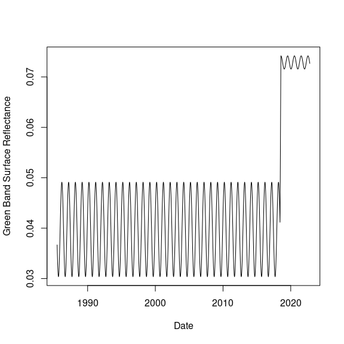

```r
#Get the green surface reflectance time series (ts) for all 8-segments at the point.
ts_green<-get_ccdc_ts(ccdc_img,x_coord,y_coord,epsg,'green',8)

#Get the near-infrared (nir) surface reflectance time series (ts) for all 8-segments at the point.
ts_nir<-get_ccdc_ts(ccdc_img,x_coord,y_coord,epsg,'nir',8)

#Plot the time series
plot(jdoy_to_date(ts_green[,'jdoy_vec']),ts_green[,'ts'],type='l',xlab='Date',ylab='Green Band Surface Reflectance')
```

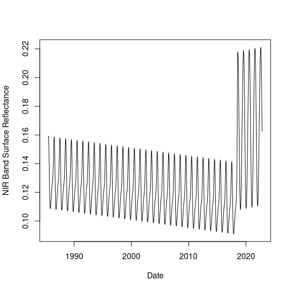

```r
plot(jdoy_to_date(ts_nir[,'jdoy_vec']),ts_nir[,'ts'],type='l',xlab='Date',ylab='NIR Band Surface Reflectance')
```

## Generate a synthentic CCDC image for a given date

```
#> 1986-07-15
```

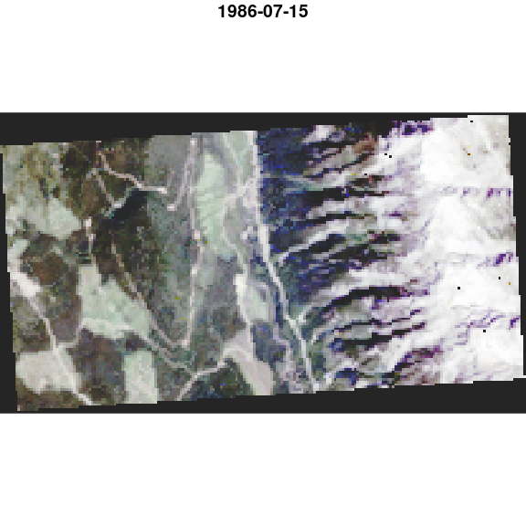

```
#> 1992-07-15
```

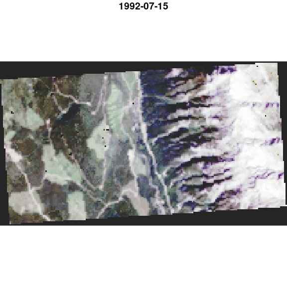

```
#> 1998-07-15
```

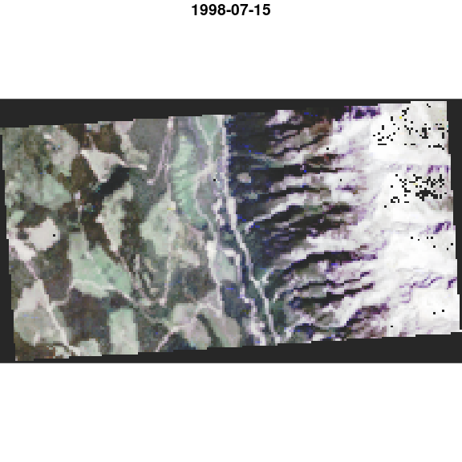

```
#> 2004-07-15
```

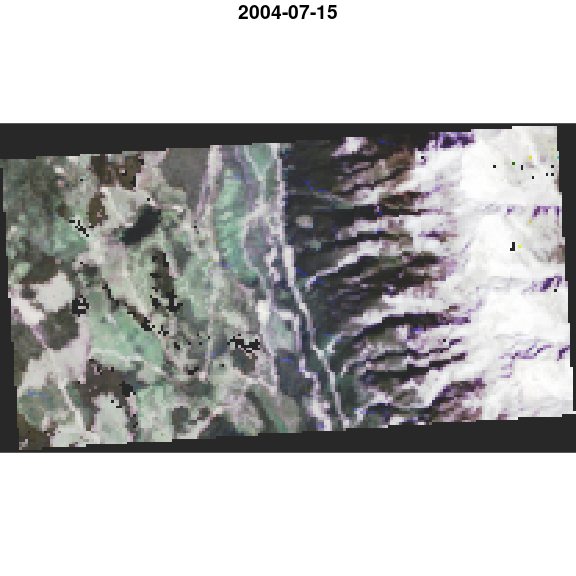

```
#> 2010-07-15
```

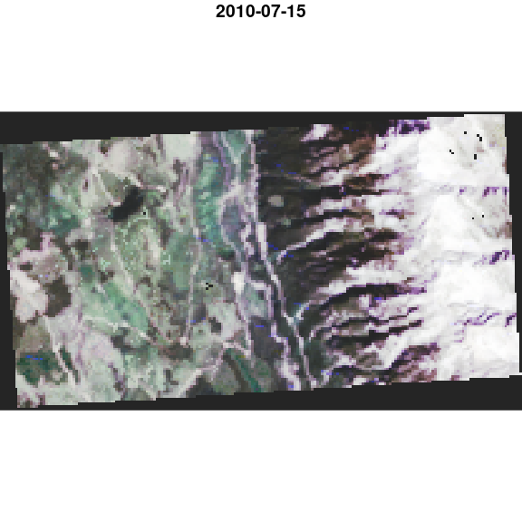

```
#> 2016-07-15
```

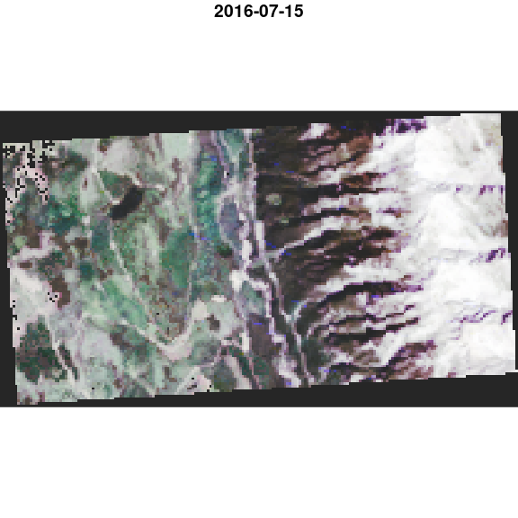

```r
dates<-paste0(seq(1986,2020,6),"-07-15")

for(date in dates)
{
  cat(date,'\n')
  synthetic<-gen_ccdc_synthetic_img(ccdc_img,date)
  plotRGB(synthetic,r=3,g=2,b=1,stretch="hist")
  title(date,line=-1)
}
```

## Generate CCDC image with coeffcients that correspond to specfic date only

It can be useful to generate raster with only the [**CCDC**](https://doi.org/10.1016/j.rse.2014.01.011) coefficients that correspond to specific point in time. This is accomplished with the *R.ccdc.tools::gen_ccdc_at_jdoy* function, which returns a raster with all [**CCDC**](https://doi.org/10.1016/j.rse.2014.01.011) coefficients but only for the segments that occur during the provided date (within the CCDC time-series, typically 1984~present day). For example, below we generate a CCDC image that contains all the [**CCDC**](https://doi.org/10.1016/j.rse.2014.01.011) coefficients but taken only from the segments that occur during July 15, 2021, and we see that the bands no longer have a segment identifier associated with them. We use July 15, 2021 because it represent near present landscape conditions when this document was written, but any date could be used. This output can be used for comparing seasonal surface reflectance curves, or input directly into any classification or regression model. Notice that the start Julian date and end Julian date of the corresponding segment is also included as additional bands. Note for large CCDC rasters this function may be slow and memory intensive, if this is case (not shown here) it is recommended to create tiles (i.e., *stars::st_tile*) from the CCDC imagery and process the tiles using *R.ccdc.tools::gen_ccdc_at_jdoy*, a VRT can then be made (i.e., *gdalbuildvrt*) for working with the output tiles as though they were one image. Just be sure to rename the bands after importing a VRT into **R** as the original band names will be lost, otherwise the following functions will fail as they look for bands by name and not index.

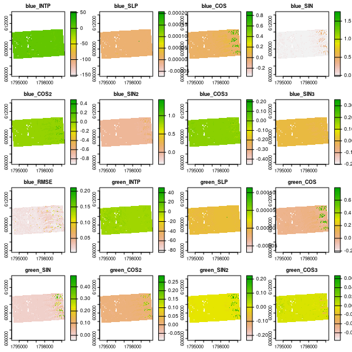

```r
#Get a CCDC image with coefficients for segments occurring during July 15, 2021 (i.e., near present day landscape conditions)
jul_15_2021<-gen_ccdc_at_jdoy(ccdc_img,"2021-07-15")
plot(jul_15_2021)
```

## Assemble a category layer

As a very simple example below we load in basic landcover polygons for use in later functions, these are simple landcover types created from visual inspection of high resolution imagery, wetland polygons are derived using the [**bcdata**](https://github.com/bcgov/bcdata) package, categories are indicated by the *landcover* field. Note any categorized polygon layer could be employed, such as BEC Zones.

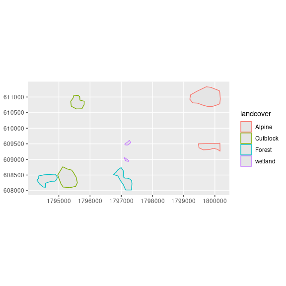

```r
#Load a example categorical layer (e.g., landcover polygons)
landcover <- landcover
landcover <- vect(landcover)


#Plot category layer
ggplot()+
  geom_sf(data=st_as_sf(landcover),aes(color=landcover))+
  coord_sf(datum=st_crs(epsg))
```

## Comparing seasonal surface reflectance curves by landcover category

A useful aspects of the [**CCDC**](https://doi.org/10.1016/j.rse.2014.01.011) is that it can be used to visually compare surface reflectance signatures for different landcover types at a given point in time, using the above *jul_15_2021* raster as input, the code bellow illustrate the application of several *R.ccdc.tools* functions that make creating such plots very simple. The function *R.ccdc.tools::plot_ccdc_ts_bypoly* selects random sample locations of specified *N* within each polygon category, and for each sample plots the synthetic surface reflectance from the date of the input image up to any number of days, typically one or two years into the future. The function *R.ccdc.tools::plot_ccdc_ts_quartiles* is very similar, but uses all available pixels and plots the daily 25, 50 and 75th percentile for each category instead of each individual time series, which is illustrated below for the *green* and *nir* Landsat bands.

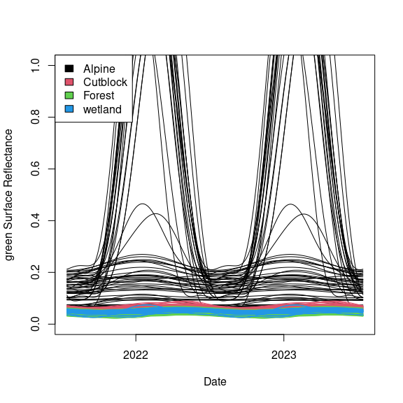

```r
#Plot CCDC 60 sample time series by polygon type (i.e., landcover) for the green band ('green') over a 730 day period
plot_ccdc_ts_bypoly(jul_15_2021,"2021-07-15",landcover,'landcover',730,'green',60)
```

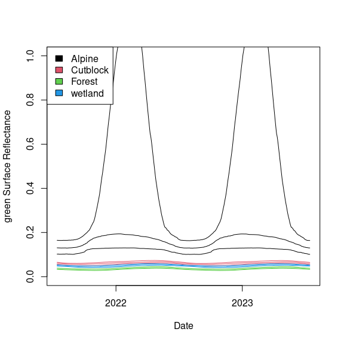

```r
#Same plot as above, only showing quartiles
plot_ccdc_ts_quartiles(jul_15_2021,"2021-07-15",landcover,'landcover',730,'green')
```

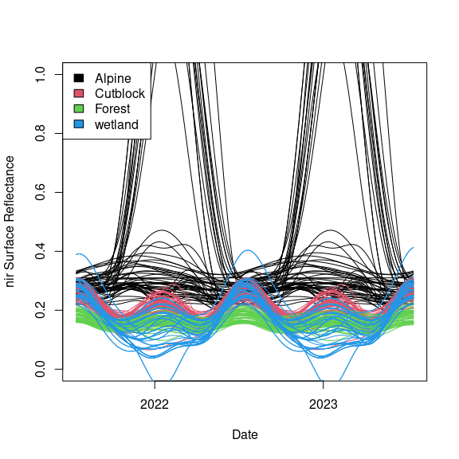

```r
#Plot CCDC 60 sample time series by polygon type (i.e., landcover) for the near-infrared band ('nir') over a 720 day period
plot_ccdc_ts_bypoly(jul_15_2021,"2021-07-15",landcover,'landcover',730,'nir',60)
```

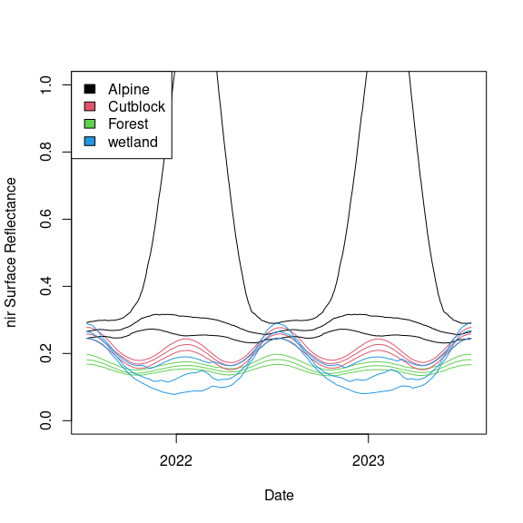

```r
#Same plot as above, only showing quartiles
plot_ccdc_ts_quartiles(jul_15_2021,"2021-07-15",landcover,'landcover',730,'nir')
```

## Comparing seasonal surface reflectance curves by landcover category (large areas of interest)

Although we use the same CCDC image here, often the size of the exported [**GEE-Script**](https://code.earthengine.google.com/?scriptPath=users%2Fhuntergdesiertonieve%2Fdefault%3ALS_timeseries_ccdc) raster can be large and many polygons may be used for exploring surface reflectance signatures between categories. The *R.ccdc.tools::plot_ccdc_by_catg* function achieves essentially the same result as *R.ccdc.tools::plot_ccdc_ts_quartiles*, but uses a random sample like *plot_ccdc_ts_bypoly* by first calling *R.ccdc.tools::sample_ccdc_by_catg*, which uses [**SAGA-GIS**](https://saga-gis.sourceforge.io/en/index.html) with [**RSAGA**](https://cran.r-project.org/web/packages/RSAGA/index.html) for more efficient computation. It also returns the computed surface reflectance data back as a data.frame. Because SAGA-GIS cannot use R objects directly, they must first be written to disk. The two functions are applied below with 300 random samples locations (total, constrained to polygons) with a minimum distance of 50 m between random locations, the result is a list with the raw-data, plot and legend crosswalk, and are also shown. Plots for the *green* and *nir* bands are generated as an example.

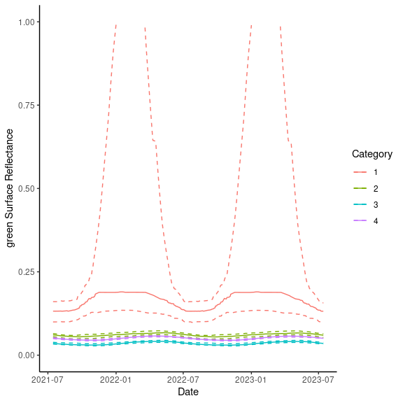

```r
#Write jul_15_2021 and landcover to temp directory
writeRaster(jul_15_2021,file.path(tempdir(),"jul_15_2021.tif"))
writeVector(landcover,file.path(tempdir(),"landcover.shp"))

#Use RSAGA for sampling CCDC coefficients (jul_15_2021) by polygon category, useful for large areas of interest with lots of polygons.
sampled<-sample_ccdc_by_catg(file.path(tempdir(),"landcover.shp"),file.path(tempdir(),"jul_15_2021.tif"),300,50,rsaga.env())
head(sampled)

#Use he result from above and create a plot from them for green band
sampled_ts<-plot_ccdc_by_catg(sampled,"2021-07-15","landcover","green")
sampled_ts
```

[output not shown]

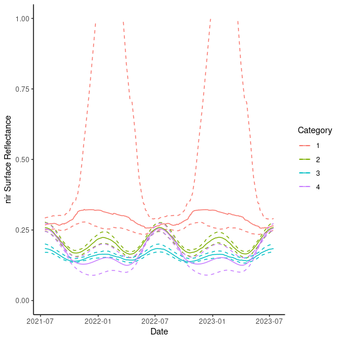

```r
#Use he result from above and create a plot from them for near-infrared band
sampled_ts<-plot_ccdc_by_catg(sampled,"2021-07-15","landcover","nir")
sampled_ts
```

```r
#Legen crosswalk
sampled_ts['crosswalk']
```

```
#> $crosswalk
#>   Category     Code
#> 1        1   Alpine
#> 2        3   Forest
#> 3        2 Cutblock
#> 4        4  wetland
```

```r
#Synthetic surface reflectance data from Jul 15, 2021 -- 730 days forward.
srdata<-as.data.frame(sampled_ts['srdata'])
head(srdata)
```

```
#>   srdata.catg srdata.jdoy srdata.SR
#> 1           1  2021-07-15 0.2597601
#> 2           1  2021-07-16 0.2602072
#> 3           1  2021-07-17 0.2606319
#> 4           1  2021-07-18 0.2610340
#> 5           1  2021-07-19 0.2614134
#> 6           1  2021-07-20 0.2617701
```

## Summarise (min, median, max) NDMI and NDWI indicies from CCDC image over specified time period (Currently only NDMI & NDWI).

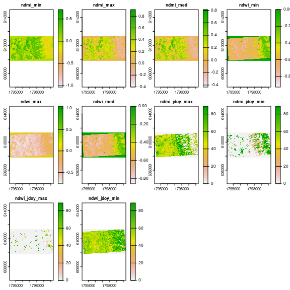

```r
sumr_2020_ndmi_stats<-ccdc_ndmi_stats(ccdc_img,"2020-06-1","2020-08-30")
plot(sumr_2020_ndmi_stats)
```

## Conclusion

The examples above demonstrate only a few possible applications of the CCDC outputs, but there are many not shown here. The *R.ccdc.tools* package is designed to simply working with CCDC images in R.